# Week 10: Lab - Using SVM on an Air Quality Dataset

## Step 3.3 - Plot the results.

Use a scatter plot. Have the x-axis represent `Temp`, the y-axis represent `Wind`, the point size and color represent the error (as defined by the actual ozone level minus the predicted ozone level). It should look similar to this:

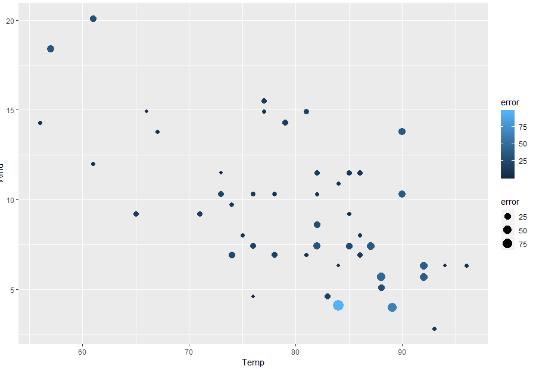

Step 3.3 Graph - Air Quality

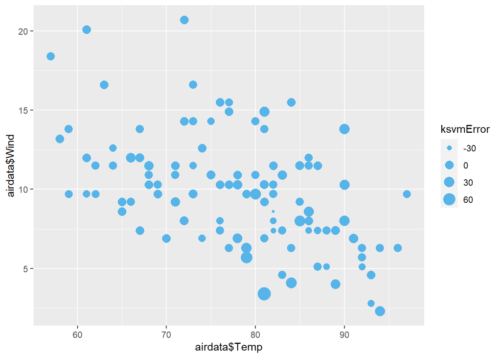

```r
# Write your code below.


new.airdata <- data.frame(airdata$Wind, airdata$Temp, ksvmError)
  colnames(new.airdata) <- c("Wind", "Temp", "Error")



plotairdata <- ggplot(data = new.airdata,aes(x=airdata$Temp,y=airdata$Wind)) + geom_point(aes(size=ksvmError), color = "#56B4E9")


plotairdata
```

```r
# This graph looks similar to the one posted in the instructions. It has a negative relationship between wind and temp. Higher temp. have less wind.
```

## Step 3.4 - 1) Compute models 2) test the model using the test dataset and find the RMSE, and 3) plot the results for `svm()` and `lm()` the same way in the prior three steps.

Use `svm()` from in the `e1071` package and `lm()` from Base R to computer two new predictive models. Generate similar charts for each model.

### Step 3.4.1 - Compute model/test the model/plot for `svm()`

```r
# Write your code below.
# SVM air data
svmAir <- svm(Ozone ~., data=testData)
OzoneModel(svmAir,airdata)
```

[output not shown]

[output cut: 397 more lines]

[output not shown]

```
## [1] NaN
```

```r
traindata.svm <- predict(svmAir, airdata)
svmError <- (airdata$Ozone - traindata.svm)
root(svmError)
```

```
## [1] 21.0213
```

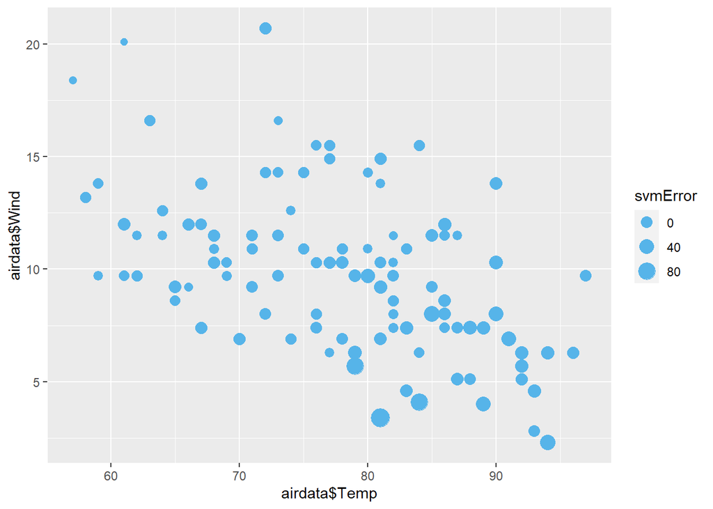

```r
svm.airdata <- data.frame(airdata$Wind, airdata$Temp, svmError)
  colnames(svm.airdata) <- c("Wind", "Temp", "Error")



plotairdataSVM <- ggplot(data = svm.airdata,aes(x=airdata$Temp,y=airdata$Wind)) + geom_point(aes(size=svmError), color = "#56B4E9")
plotairdataSVM
```

### Step 3.4.2 - Compute model/test the model/plot for `lm()`

```r
# Write your code below.
# LM air Data

lmAir <- lm(Ozone ~., data=testData)
OzoneModel(lmAir,airdata)
```

[output not shown]

[output cut: 397 more lines]

[output not shown]

```
## [1] NaN
```

```r
traindata.lm <- predict(lmAir, airdata)
lmError <- (airdata$Ozone - traindata.lm)
root(lmError)
```

```
## [1] 21.44595
```

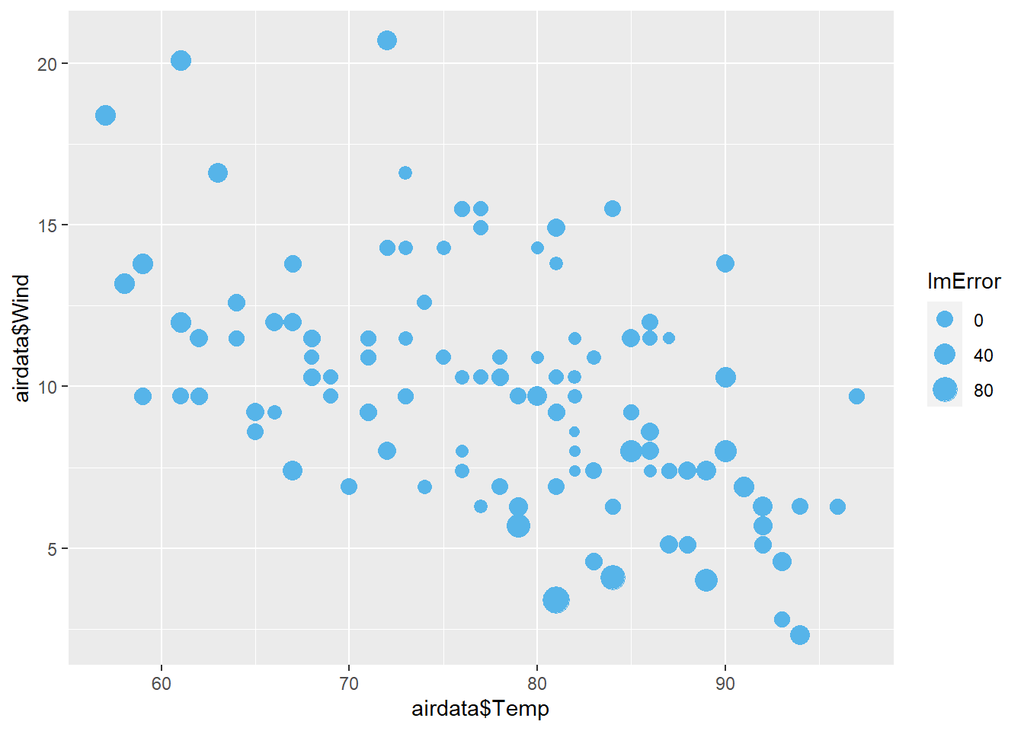

```r
lm.airdata <- data.frame(airdata$Wind, airdata$Temp, svmError)
  colnames(lm.airdata) <- c("Wind", "Temp", "Error")



plotairdatalM <- ggplot(data = lm.airdata,aes(x=airdata$Temp,y=airdata$Wind)) + geom_point(aes(size=lmError), color = "#56B4E9")
plotairdatalM
```

## Step 3.5 - Plot all three model results together

Show the results for the KSVM, SVM, and LM models in one window. Use the `grid.arrange()` function to do this. All three models should be scatterplots.

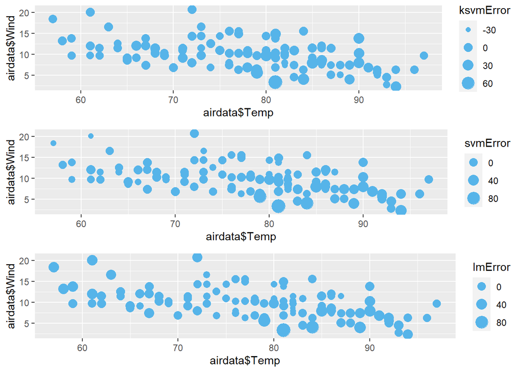

```r
# Write your code below.
grid.arrange(plotairdata,plotairdataSVM,plotairdatalM)
```

# Step 4: Create a “goodOzone” variable (1 point)

This variable should be either 0 or 1. It should be 0 if the ozone is below the average for all the data observations, and 1 if it is equal to or above the average ozone observed. Pay attention to the binary factor variable (goodOzone) so you cannot use RMSE for calculating error for models you build using this data.

```r
# Write your code below.
#153 in airdata, 74 in traindata. I made in i in 74 since the next step requires us to use the traindata...

goodOzone <-c()
  for (i in 1:111) {
    if (airdata$Ozone[i] < mean(airdata$Ozone)){
    goodOzone<-append(goodOzone,0)
  }
  else goodOzone<-append(goodOzone,1)
  }

#adding the column in the dataframe
airdata<-data.frame(airdata,goodOzone)
```

# Step 5: Predict “good” and “bad” ozone days. (3 points)

Let’s see if we can do a better job predicting “good” and “bad” days.

## Step 5.1 - Build a model

Using `ksvm()`, create a model to try to predict `goodOzone`. You can use all the possible attributes, or select the attributes that you think would be the most helpful. Of course, use the training dataset.

```r
# Write your code below.

trainData<-data.frame(airdata,goodOzone)

OzoneModel.Good <- function(G, trainData){
  OzoneModel.Good <- predict(G, trainData)
  results <- table(OzoneModel.Good, trainData$goodOzone)
  print(results)
  Error <- (results[1,1]+results[2,2])/(results[1,1]+results[1,2]+(results[2,1]+results[2,2])*100)
  round(Error)
  return(Error)
}

KSVMModel.Good <- ksvm(goodOzone~.,data=trainData)
OzoneModel.Good(KSVMModel.Good ,trainData)
```

[output not shown]

[output cut: 58 more lines]

[output not shown]

```
## [1] 0.00990099
```

```r
GoodOzone <- OzoneModel.Good(KSVMModel.Good ,trainData)
```

[output not shown]

[output cut: 58 more lines]

[output not shown]

## Step 5.2 - Test the model and find the percent of `goodOzone`

Test the model on the test dataset, and compute the percent of “goodOzone” that was correctly predicted. Do not use RMSE here…

```r
# Write your code below.

OzoneModel.Good(KSVMModel.Good, trainData)
```

[output not shown]

[output cut: 58 more lines]

[output not shown]

```
## [1] 0.00990099
```

```r
# Create a data set with the errors we generated.
root <- function(error){
  sqrt(mean(error^2))
}

traindata.ksvmGood <- predict(KSVMModel.Good, trainData)
ksvmError.Good <- (airdata$Ozone - traindata.ksvmGood)
root(ksvmError.Good)
```

```
## [1] 53.02716
```

## Step 5.3 - Plot the results

```
# determine the prediction is "correct" or "wrong" for each case,

# create a new dataframe contains correct, temperature and wind, and goodZone

# change column names
  colnames(Plot_ksvm) <- c("correct","Temp","Wind","goodOzone","Predict")
# plot result using ggplot
```

Use a scatter plot. Have the x-axis represent `Temp`, the y-axis represent `Wind`, the shape representing what was predicted (good or bad day), the color representing the actual value of `goodOzone` (i.e. if the actual ozone level was good) and the size represent if the prediction was correct (larger symbols should be the observations the model got wrong). The plot should look similar to this:

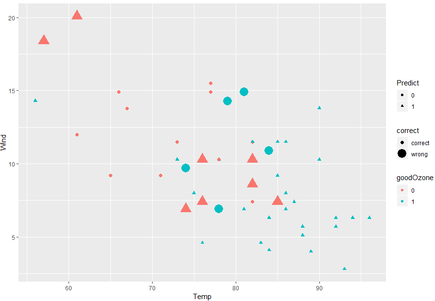

Step 5.3 Graph - Good Ozone

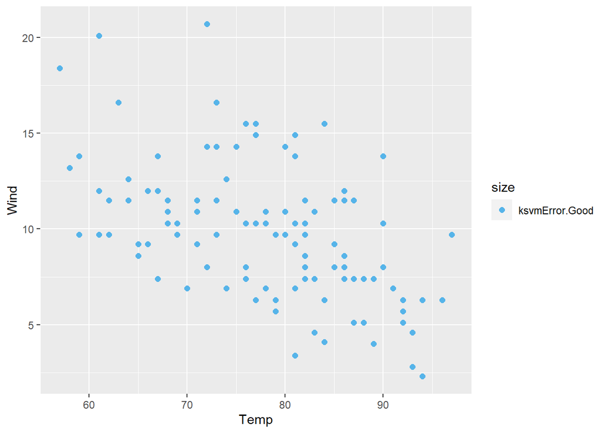

```r
# Write your code below.

new.Goodairdata <- data.frame(GoodOzone,airdata$Temp, airdata$Wind, airdata$goodOzone, ksvmError.Good)
  colnames(new.Goodairdata) <- c("correct","Temp","Wind","goodOzone","Predict")



plotairdata.Good <- ggplot(data = new.Goodairdata,aes(x=Temp,y=Wind)) + geom_point(aes(size="ksvmError.Good"), color = "#56B4E9")


plotairdata.Good
```

## Step 5.4 - Compute models and plot the results for ksvm, svm, and nb

Build a model using ksvm, svm, nb functions, and use all other variables to predict.  
Use `svm()` and `naiveBayes()` from in the e1071 package.

### Step 5.4.1 - Build a model using the `ksvm()` function,and use all other variables to predict.

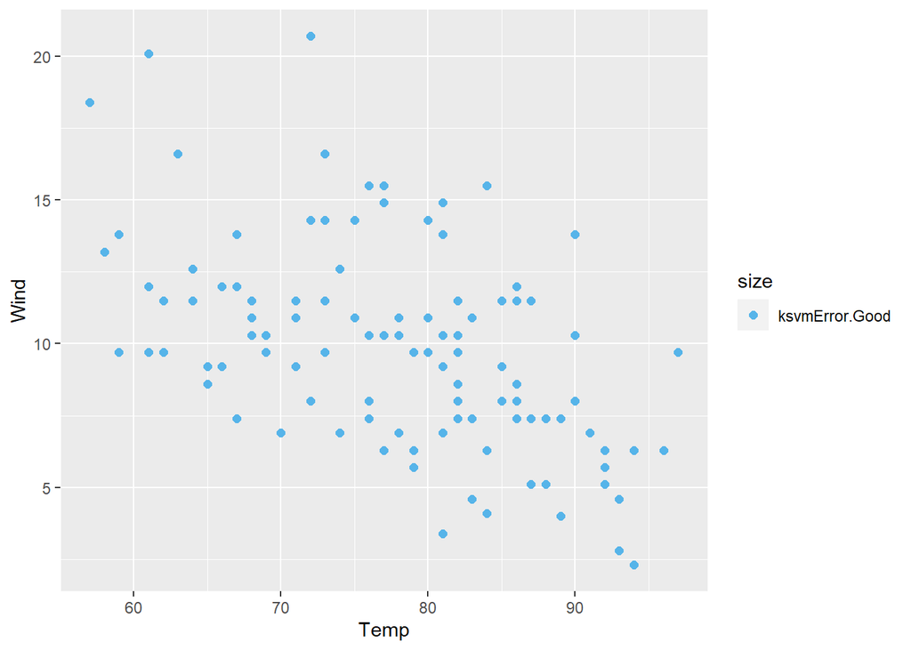

```r
# Write your code below.
KSVMModel.Good <- ksvm(goodOzone~.,data=trainData)
plotairdata.GoodKSVM <- ggplot(data = new.Goodairdata,aes(x=airdata$Temp,y=airdata$Wind)) + geom_point(aes(size="Predict"), color = "#56B4E9")
plotairdata.Good
```

### Step 5.4.2 - Test the model: Predict the new values from the test data and save the results as a new object.

Create a dataframe that contains the exact “goodOzone” value and the predicted “goodOzone”.  
Compute the percentage of correct cases

```r
# Write your code below.

Correct.PredictedOzones <- data.frame(traindata.ksvmGood, ksvmError.Good)
  colnames(Correct.PredictedOzones) <- c("Correct","Predict")
```

# Step 5.4.3 Plot the results.

Determine whether the prediction is “correct” or “wrong” for each case Plot results using ggplot. Size representing correct/wrong; color representing actual good/bad day; shape representing predicted good/bad day.

[figure not shown]

```r
# Write your code below.

  Correct.PredictedOzones.Plot <- ggplot(data = Correct.PredictedOzones,aes(x=Correct,y=Predict))
Correct.PredictedOzones.Plot
```

# Step 5.4.4 - Compute models and plot the results for “svm” and “nb”

Do the same three steps as above for “svm”– `svm()` and “nb”– `naiveBayes()`: 1) build models, 2) test the model, 3) plot the results.

```r
# Write your code below.
SVMModel.Good <- svm(goodOzone ~ ., data = airdata)
OzoneModel.Good(SVMModel.Good, airdata)
```

[output not shown]

[output cut: 58 more lines]

[output not shown]

```
## [1] 0.00990099
```

```r
SVMModel.Good.first <- predict(SVMModel.Good, airdata)
SVMModel.Good.error <- (airdata$goodOzone - SVMModel.Good.first)
root(SVMModel.Good.error)
```

```
## [1] 0.1795969
```

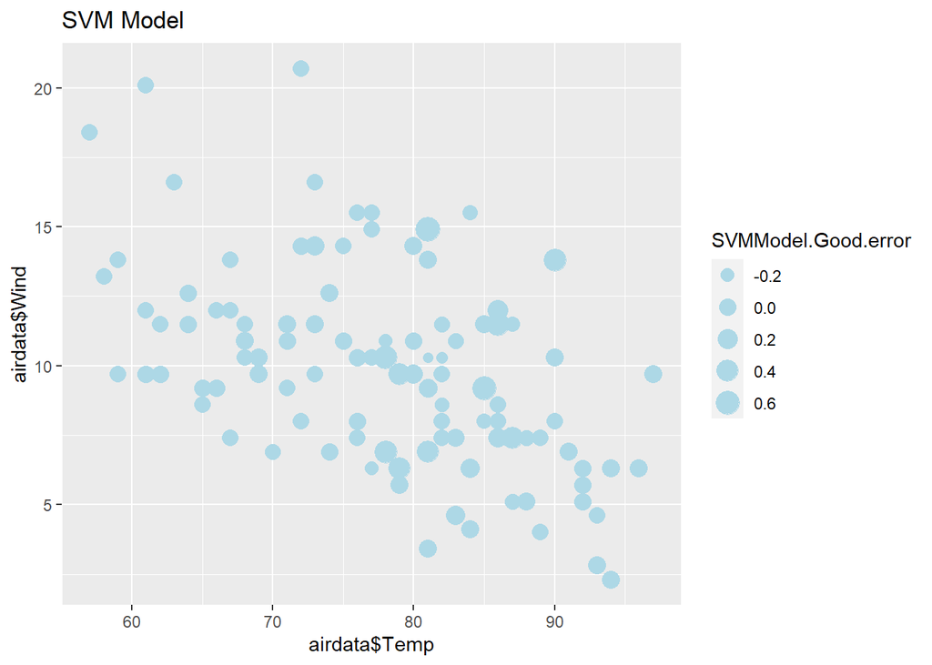

```r
SVMDF<- data.frame(airdata$Wind,airdata$Temp,SVMModel.Good.error)
colnames(SVMDF) <- c("Wind","Temp","Error")
SVMDF.Plot <- ggplot(data = SVMDF,aes(x=airdata$Temp,y=airdata$Wind)) + geom_point(aes(size=SVMModel.Good.error), color = "lightblue") + ggtitle("SVM Model")
SVMDF.Plot
```

```r
# NaivBayes

NaivBayesModel <- naiveBayes(goodOzone ~ ., data = airdata)
OzoneModel.Good(NaivBayesModel, airdata)
```

```
##
## OzoneModel.Good  0  1
##               0 68  2
##               1  1 40
```

```
## [1] 0.02589928
```

```r
NaivBayesModel.Error <- predict(NaivBayesModel, airdata)

NaivBayesDF <- data.frame(airdata$goodOzone)
NaivBayesModel.Predicted <- predict(NaivBayesModel, NaivBayesDF)
NaivBayesModel.Predicted
```

```
##   [1] 0 0 0 0 0 0 0 0 0 0 0 0 0 0 0 0 0 0 0 0 0 0 0 0 0 0 0 0 0 0 0 0 0 0 0 0 0
##  [38] 0 0 0 0 0 0 0 0 0 0 0 0 0 0 0 0 0 0 0 0 0 0 0 0 0 0 0 0 0 0 0 0 0 0 0 0 0
##  [75] 0 0 0 0 0 0 0 0 0 0 0 0 0 0 0 0 0 0 0 0 0 0 0 0 0 0 0 0 0 0 0 0 0 0 0 0 0
## Levels: 0 1
```

[figure not shown]

```r
NaivBayesDF.2 <- data.frame(airdata$Wind,airdata$Temp,NaivBayesModel.Error)
colnames(NaivBayesDF.2) <- c("Wind","Temp","Error")

NaivBayesDF.Plot <- ggplot(data = NaivBayesDF.2,aes(x=airdata$Temp,y=airdata$Wind)) + geom_point(aes(size=NaivBayesModel.Error), color = "Purple") + ggtitle("SVM Model")
NaivBayesDF.Plot
```

## Step 5.5 - Plot all three model results together

Show the results for the KSVM, SVM, and NB models in one window. Use the `grid.arrange()` function to do this. All three models should be scatterplots.

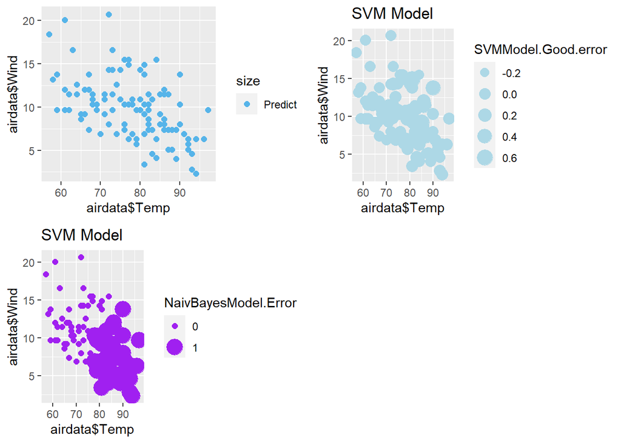

```r
# Write your code below.

grid.arrange(plotairdata.GoodKSVM,SVMDF.Plot, NaivBayesDF.Plot, ncol = 2)
```

# Step 6: Which are the best Models for this data? (2 points)

Review what you have done (pay attention the visualization as well as the RMSE in step 3 and accuracy calculation in step 5) and state which is the best and why. Please show the comparison of those error calculation results from Step 3 and Step 5 here.

# Step 7: Upload your compiled file. (1 point)

Your compiled file should contain the answers to the questions.